# Categorical Data Plots

Now let's discuss using seaborn to plot categorical data! There are a few main plot types for this:

- factorplot
- boxplot
- violinplot
- stripplot
- swarmplot
- barplot
- countplot

Let's go through examples of each!

```python
import seaborn as sns
%matplotlib inline
```

```python
tips = sns.load_dataset('tips')
tips.head()
```

|  | total_bill | tip | sex | smoker | day | time | size |
| --- | --- | --- | --- | --- | --- | --- | --- |
| 0 | 16.99 | 1.01 | Female | No | Sun | Dinner | 2 |
| 1 | 10.34 | 1.66 | Male | No | Sun | Dinner | 3 |
| 2 | 21.01 | 3.50 | Male | No | Sun | Dinner | 3 |
| 3 | 23.68 | 3.31 | Male | No | Sun | Dinner | 2 |
| 4 | 24.59 | 3.61 | Female | No | Sun | Dinner | 4 |

## barplot and countplot

These very similar plots allow you to get aggregate data off a categorical feature in your data. **barplot** is a general plot that allows you to aggregate the categorical data based off some function, by default the mean:

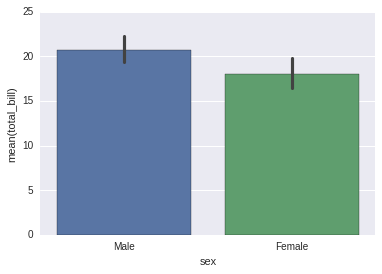

```python
sns.barplot(x='sex',y='total_bill',data=tips)
```

```python
import numpy as np
```

You can change the estimator object to your own function, that converts a vector to a scalar:

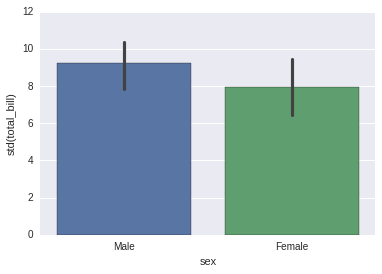

```python
sns.barplot(x='sex',y='total_bill',data=tips,estimator=np.std)
```

### countplot

This is essentially the same as barplot except the estimator is explicitly counting the number of occurrences. Which is why we only pass the x value:

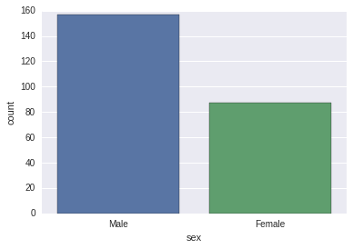

```python
sns.countplot(x='sex',data=tips)
```

## Boxplot

Boxplots are used to shown the distribution of categorical data.

- Boxplot shows the distribution of quantitative data facilitating comparisons between variables
- Boxplot shows the **quartiles** (*four equal-size groups or quantiles*) of the dataset while the "whiskers" extend to show the rest of the distribution
  - except for points that are determined to be **outliers** using a method that is a function of the inter-quartile range.

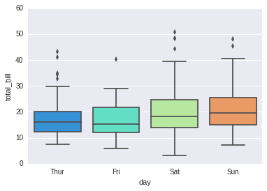

```python
sns.boxplot(x="day", y="total_bill", data=tips,palette='rainbow')
```

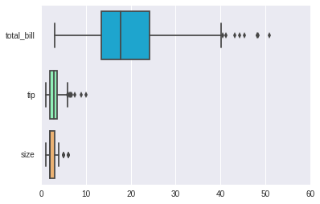

```python
# Can do entire dataframe with orient='h'
sns.boxplot(data=tips,palette='rainbow',orient='h')
```

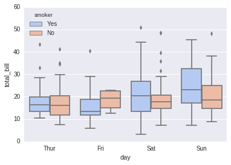

```python
sns.boxplot(x="day", y="total_bill", hue="smoker",data=tips, palette="coolwarm")
```

## violinplot

A violin plot plays a similar role as a box and whisker plot.

- Unlike a boxplot, in which all of the plot components correspond to actual datapoints, the violin plot features a **kernel density estimation** of the underlying distribution.

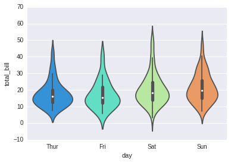

```python
sns.violinplot(x="day", y="total_bill", data=tips,palette='rainbow')
```

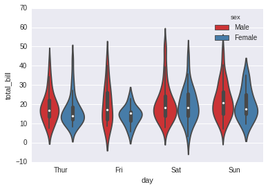

```python
sns.violinplot(x="day", y="total_bill", data=tips,hue='sex',palette='Set1')
```

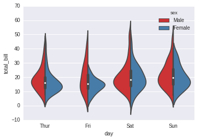

```python
sns.violinplot(x="day", y="total_bill", data=tips,hue='sex',split=True,palette='Set1')
```

### Combining Categorical Plots

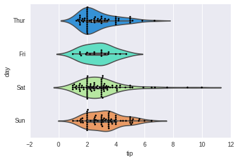

```python
sns.violinplot(x="tip", y="day", data=tips,palette='rainbow')
sns.swarmplot(x="tip", y="day", data=tips,color='black',size=3)
```